# Story - 1 : Infrastructure Investment & Jobs Act Funding Allocation

Daria Dubovskaia

```r
#' nice_table
#'
#' @param df
#' @param fw
nice_table <- function(df, cap=NULL, cols=NULL, dig=3, fw=F){
  if (is.null(cols)) {c <- colnames(df)} else {c <- cols}
  table <- df %>%
    kable(caption=cap, col.names=c, digits=dig) %>%
    kable_styling(
      bootstrap_options = c("striped", "hover", "condensed"),
      html_font = 'monospace',
      full_width = fw)
  return(table)
}
```

## Overview

The Infrastructure Investment and Jobs Act is a significant commitment by the federal government to improving the nation’s infrastructure. This analysis seeks to assess the equity of the Act’s funding allocation across states and territories, as well as whether there is any evidence of political bias in the distribution of funds. Understanding how these funds are allocated is critical for ensuring that the Act achieves its stated goal of equitable infrastructure development.

## 1. Data Preparation

### 1.1 Summary Statistics

**Funding Data**

The funding data contained **57** observations of 2 variables. It included columns for each state, territory, or tribal nation, as well as total funding in billions. The data source: Github repo

**Population Data**

The population data had a complex structure, with row headers and numerous unnamed columns. The relevant data appeared to be organized into columns with headers such as “April 1, 2020 Population Estimates Base” and “Population Estimate (as of July 1)” for various years. As a results of data preparation step, this dataset should have contained **57** observations of 2 variables. It included columns for each state, territory, or tribal nation, as well as total population for 2020 year. The data source: [United States Census Bureau](https://www.census.gov/data/datasets/time-series/demo/popest/2020s-state-total.html), [List of U.S. states and territories by population](https://en.wikipedia.org/wiki/List_of_U.S._states_and_territories_by_population), [Native Americans in the United States](https://en.wikipedia.org/wiki/Native_Americans_in_the_United_States)

**Election Results Data**

The election results data included columns for the state, final call (indicating which party won), Democratic and Republican votes, other votes, percentages for each, and margin of victory. There were additional columns for state IDs, electoral votes, and other metadata. As a results of data preparation step, this dataset should have contained **51** observations of 4 variables. The data source: [The Cook Political Report with Amy Walter](https://www.cookpolitical.com/2020-national-popular-vote-tracker)

All three datasets had no missing values for their key columns, indicating that the data was complete in terms of the presence of values.

```r
# Load data from Github
df1 <- read.csv("https://raw.githubusercontent.com/ex-pr/DATA_608/main/Popular%20vote%20backend%20-%20Sheet1.csv")

df2 <- read.xlsx("https://github.com/ex-pr/DATA_608/blob/main/NST-EST2023-CHG.xlsx?raw=true", 1)

df3 <- read.xlsx("https://github.com/ex-pr/DATA_608/blob/main/IIJA%20FUNDING%20AS%20OF%20MARCH%202023(1).xlsx?raw=true", 1)
```

```r
elections <- df1
population <- df2
funding <- df3
```

```r
#show the data in tables
elections %>%
  nice_table(cap='The 2020 Presidential election') %>%
  scroll_box(width='100%', height = "400px")
```

The 2020 Presidential election

| state | called | final | dem_votes | rep_votes | other_votes | dem_percent | rep_percent | other_percent | dem_this_margin | margin_shift | vote_change | stateid | EV | X | Y | State_num | Center_X | Center_Y | X.1 | X2016.Margin | Total.2016.Votes |
| --- | --- | --- | --- | --- | --- | --- | --- | --- | --- | --- | --- | --- | --- | --- | --- | --- | --- | --- | --- | --- | --- |
| U.S. Total | D | Yes | 81,282,916 | 74,223,369 | 2,891,441 | 51.3% | 46.9% | 1.8% | 4.5% | 2.4% | 15.9% |  | NA | NA | NA | NA | NA | NA | NA | 0.021 | 136,639,848 |
| 15 Key Battlegrounds |  |  | 31,908,248 | 33,002,287 | 950,354 | 48.4% | 50.1% | 1.4% | -1.7% | 2.0% | 17.2% |  | NA | NA | NA | NA | NA | NA | NA | -0.036 | 56,209,173 |
| Non-Battlegrounds |  |  | 49,374,668 | 41,221,082 | 1,941,087 | 53.4% | 44.5% | 2.1% | 8.8% | 2.7% | 15.1% |  | NA | NA | NA | NA | NA | NA | NA | 0.061 | 80,430,331 |
| 15 Key Battlegrounds |  |  |  |  |  |  |  |  |  |  |  |  | NA | NA | NA | NA | NA | NA | NA | NA |  |
| Arizona | D | Yes | 1,672,143 | 1,661,686 | 53,497 | 49.4% | 49.1% | 1.6% | 0.3% | 3.9% | 31.6% | AZ | 11 | 2 | 2 | 4 | 205 | 374 | NA | -0.035 | 2,573,165 |
| Florida | R | Yes | 5,297,045 | 5,668,731 | 101,680 | 47.9% | 51.2% | 0.9% | -3.4% | -2.2% | 17.5% | FL | 29 | 8 | 0 | 12 | 787 | 520 | NA | -0.012 | 9,420,039 |
| Georgia | D | Yes | 2,473,633 | 2,461,854 | 62,229 | 49.5% | 49.3% | 1.2% | 0.2% | 5.4% | 22.1% | GA | 16 | 7 | 1 | 13 | 734 | 419 | NA | -0.051 | 4,092,373 |
| Iowa | R | Yes | 759,061 | 897,672 | 34,138 | 44.9% | 53.1% | 2.0% | -8.2% | 1.2% | 8.0% | IA | 6 | 5 | 4 | 19 | 536 | 223 | NA | -0.094 | 1,566,031 |
| Maine 2nd District | R | Yes | 168,696 | 196,692 | 10,961 | 44.8% | 52.3% | 2.9% | -7.4% | 2.8% | 6.5% | ME2 | 1 | 12 | 8 | 102 | 919 | 92 | NA | -0.103 | 353,416 |
| Michigan | D | Yes | 2,804,040 | 2,649,852 | 85,410 | 50.6% | 47.8% | 1.5% | 2.8% | 3.0% | 15.4% | MI | 16 | 7 | 5 | 26 | 681 | 190 | NA | -0.002 | 4,799,284 |
| Minnesota | D | Yes | 1,717,077 | 1,484,065 | 76,029 | 52.4% | 45.3% | 2.3% | 7.1% | 5.6% | 11.3% | MN | 10 | 5 | 5 | 27 | 519 | 120 | NA | 0.015 | 2,944,813 |
| Nebraska 2nd District | D | Yes | 176,468 | 154,377 | 6,909 | 52.2% | 45.7% | 2.0% | 6.5% | 8.8% | 15.8% | NE2 | 1 | 12 | 6 | 104 | 438 | 238 | NA | -0.022 | 291,680 |
| Nevada | D | Yes | 703,486 | 669,890 | 32,000 | 50.1% | 47.7% | 2.3% | 2.4% | 0.0% | 24.9% | NV | 6 | 2 | 4 | 32 | 136 | 240 | NA | 0.024 | 1,125,385 |
| New Hampshire | D | Yes | 424,921 | 365,654 | 15,607 | 52.7% | 45.4% | 1.9% | 7.4% | 7.0% | 8.3% | NH | 4 | 11 | 6 | 33 | 895 | 146 | NA | 0.004 | 744,158 |
| North Carolina | R | Yes | 2,684,292 | 2,758,775 | 81,737 | 48.6% | 49.9% | 1.5% | -1.3% | 2.3% | 16.5% | NC | 15 | 7 | 2 | 37 | 808 | 349 | NA | -0.037 | 4,741,564 |
| Ohio | R | Yes | 2,679,165 | 3,154,834 | 88,203 | 45.2% | 53.3% | 1.5% | -8.0% | 0.1% | 7.7% | OH | 18 | 7 | 4 | 39 | 720 | 250 | NA | -0.081 | 5,496,487 |
| Pennsylvania | D | Yes | 3,458,229 | 3,377,674 | 79,380 | 50.0% | 48.8% | 1.1% | 1.2% | 1.9% | 13.1% | PA | 20 | 8 | 4 | 42 | 806 | 221 | NA | -0.007 | 6,115,402 |
| Texas | R | Yes | 5,259,126 | 5,890,347 | 165,583 | 46.5% | 52.1% | 1.5% | -5.6% | 3.4% | 26.2% | TX | 38 | 3 | 0 | 48 | 444 | 471 | NA | -0.090 | 8,969,226 |
| Wisconsin | D | Yes | 1,630,866 | 1,610,184 | 56,991 | 49.4% | 48.8% | 1.7% | 0.6% | 1.4% | 10.8% | WI | 10 | 6 | 6 | 55 | 601 | 169 | NA | -0.008 | 2,976,150 |
| Non-Battlegrounds |  |  |  |  |  |  |  |  |  |  |  |  | NA | NA | NA | NA | NA | NA | NA | NA |  |
| Alabama | R | Yes | 849,624 | 1,441,170 | 32,488 | 36.6% | 62.0% | 1.4% | -25.5% | 2.3% | 9.4% | AL | 9 | 6 | 1 | 1 | 674 | 424 | NA | -0.277 | 2,123,372 |
| Alaska | R | Yes | 153,778 | 189,951 | 15,801 | 42.8% | 52.8% | 4.4% | -10.1% | 4.7% | 12.8% | AK | 3 | 0 | 6 | 2 | 105 | 512 | NA | -0.147 | 318,608 |
| Arkansas | R | Yes | 423,932 | 760,647 | 34,490 | 34.8% | 62.4% | 2.8% | -27.6% | -0.7% | 7.8% | AR | 6 | 5 | 2 | 5 | 564 | 386 | NA | -0.269 | 1,130,635 |
| California | D | Yes | 11,110,250 | 6,006,429 | 384,192 | 63.5% | 34.3% | 2.2% | 29.2% | -0.9% | 23.4% | CA | 55 | 1 | 3 | 6 | 75 | 283 | NA | 0.301 | 14,181,595 |
| Colorado | D | Yes | 1,804,352 | 1,364,607 | 87,993 | 55.4% | 41.9% | 2.7% | 13.5% | 8.6% | 17.1% | CO | 9 | 3 | 3 | 8 | 330 | 284 | NA | 0.049 | 2,780,220 |
| Connecticut | D | Yes | 1,080,831 | 714,717 | 28,309 | 59.3% | 39.2% | 1.6% | 20.1% | 6.4% | 10.9% | CT | 7 | 10 | 4 | 9 | 886 | 190 | NA | 0.136 | 1,644,920 |
| Delaware | D | Yes | 296,268 | 200,603 | 7,475 | 58.7% | 39.8% | 1.5% | 19.0% | 7.6% | 14.2% | DE | 3 | 11 | 3 | 10 | 853 | 258 | NA | 0.114 | 441,590 |
| District of Columbia | D | Yes | 317,323 | 18,586 | 8,447 | 92.1% | 5.4% | 2.5% | 86.8% | 0.0% | 10.6% | DC | 3 | 9 | 3 | 11 | 829 | 264 | NA | 0.868 | 311,268 |
| Hawaii | D | Yes | 366,130 | 196,864 | 11,475 | 63.7% | 34.3% | 2.0% | 29.5% | -2.7% | 33.9% | HI | 4 | 0 | 0 | 15 | 272 | 570 | NA | 0.322 | 428,937 |
| Idaho | R | Yes | 287,021 | 554,119 | 26,091 | 33.1% | 63.9% | 3.0% | -30.8% | 1.0% | 25.6% | ID | 4 | 2 | 5 | 16 | 195 | 148 | NA | -0.318 | 690,255 |
| Illinois | D | Yes | 3,471,915 | 2,446,891 | 114,938 | 57.5% | 40.6% | 1.9% | 17.0% | -0.1% | 9.0% | IL | 20 | 6 | 5 | 17 | 614 | 264 | NA | 0.171 | 5,536,424 |
| Indiana | R | Yes | 1,242,413 | 1,729,516 | 61,183 | 41.0% | 57.0% | 2.0% | -16.1% | 3.1% | 10.9% | IN | 11 | 6 | 4 | 18 | 669 | 264 | NA | -0.192 | 2,734,958 |
| Kansas | R | Yes | 570,323 | 771,406 | 30,574 | 41.6% | 56.2% | 2.2% | -14.7% | 5.9% | 15.9% | KS | 6 | 4 | 2 | 20 | 457 | 307 | NA | -0.206 | 1,184,402 |
| Kentucky | R | Yes | 772,474 | 1,326,646 | 37,648 | 36.2% | 62.1% | 1.8% | -25.9% | 3.9% | 11.1% | KY | 8 | 6 | 3 | 21 | 706 | 314 | NA | -0.298 | 1,924,149 |
| Louisiana | R | Yes | 856,034 | 1,255,776 | 36,252 | 39.9% | 58.5% | 1.7% | -18.6% | 1.0% | 5.9% | LA | 8 | 4 | 1 | 22 | 560 | 456 | NA | -0.196 | 2,029,032 |
| Maine | D | Yes | 435,072 | 360,737 | 23,652 | 53.1% | 44.0% | 2.9% | 9.1% | 6.1% | 9.6% | ME | 2 | 11 | 7 | 23 | 919 | 92 | NA | 0.030 | 747,927 |
| Maine 1st District | D | Yes | 266,376 | 164,045 | 12,691 | 60.1% | 37.0% | 2.9% | 23.1% | 8.3% | 12.4% | ME1 | 1 | 12 | 9 | 101 | 919 | 92 | NA | 0.148 | 394,329 |
| Maryland | D | Yes | 1,985,023 | 976,414 | 75,593 | 65.4% | 32.2% | 2.5% | 33.2% | 6.8% | 9.2% | MD | 10 | 10 | 3 | 24 | 825 | 254 | NA | 0.264 | 2,781,446 |
| Massachusetts | D | Yes | 2,382,202 | 1,167,202 | 81,998 | 65.6% | 32.1% | 2.3% | 33.5% | 6.3% | 9.2% | MA | 11 | 10 | 5 | 25 | 895 | 169 | NA | 0.272 | 3,325,046 |
| Mississippi | R | Yes | 539,508 | 756,789 | 17,597 | 41.1% | 57.6% | 1.3% | -16.5% | 1.3% | 8.6% | MS | 6 | 5 | 1 | 28 | 617 | 427 | NA | -0.178 | 1,209,357 |
| Missouri | R | Yes | 1,253,014 | 1,718,736 | 54,212 | 41.4% | 56.8% | 1.8% | -15.4% | 3.2% | 7.7% | MO | 10 | 5 | 3 | 29 | 557 | 305 | NA | -0.186 | 2,808,605 |
| Montana | R | Yes | 244,786 | 343,602 | 15,286 | 40.5% | 56.9% | 2.5% | -16.4% | 4.1% | 21.4% | MT | 3 | 3 | 5 | 30 | 289 | 95 | NA | -0.204 | 497,147 |
| Nebraska | R | Yes | 374,583 | 556,846 | 20,283 | 39.4% | 58.5% | 2.1% | -19.2% | 5.9% | 12.7% | NE | 2 | 4 | 3 | 31 | 438 | 238 | NA | -0.250 | 844,289 |
| Nebraska 1st District | R | Yes | 132,261 | 180,290 | 7,495 | 41.3% | 56.3% | 2.3% | -15.0% | 5.7% | 13.4% | NE1 | 1 | 12 | 7 | 103 | 438 | 238 | NA | -0.207 | 282,338 |
| Nebraska 3rd District | R | Yes | 65,854 | 222,179 | 5,879 | 22.4% | 75.6% | 2.0% | -53.2% | 1.0% | 8.8% | NE3 | 1 | 12 | 5 | 105 | 438 | 238 | NA | -0.542 | 270,109 |
| New Jersey | D | Yes | 2,608,335 | 1,883,274 | 57,744 | 57.3% | 41.4% | 1.3% | 15.9% | 1.8% | 17.4% | NJ | 14 | 9 | 4 | 34 | 865 | 231 | NA | 0.141 | 3,874,046 |
| New Mexico | D | Yes | 501,614 | 401,894 | 20,457 | 54.3% | 43.5% | 2.2% | 10.8% | 2.6% | 15.7% | NM | 5 | 3 | 2 | 35 | 309 | 385 | NA | 0.082 | 798,318 |
| New York | D | Yes | 5,244,886 | 3,251,997 | 119,978 | 60.9% | 37.7% | 1.4% | 23.1% | 0.6% | 11.6% | NY | 29 | 9 | 5 | 36 | 838 | 168 | NA | 0.225 | 7,721,453 |
| North Dakota | R | Yes | 114,902 | 235,595 | 11,322 | 31.8% | 65.1% | 3.1% | -33.4% | 2.4% | 5.1% | ND | 3 | 4 | 5 | 38 | 426 | 97 | NA | -0.357 | 344,360 |
| Oklahoma | R | Yes | 503,890 | 1,020,280 | 36,529 | 32.3% | 65.4% | 2.3% | -33.1% | 3.3% | 7.4% | OK | 7 | 3 | 1 | 40 | 477 | 377 | NA | -0.364 | 1,452,992 |
| Oregon | D | Yes | 1,340,383 | 958,448 | 75,490 | 56.5% | 40.4% | 3.2% | 16.1% | 5.1% | 18.6% | OR | 7 | 1 | 4 | 41 | 97 | 134 | NA | 0.110 | 2,001,336 |
| Rhode Island | D | Yes | 307,486 | 199,922 | 10,349 | 59.4% | 38.6% | 2.0% | 20.8% | 5.3% | 11.6% | RI | 4 | 11 | 4 | 44 | 904 | 183 | NA | 0.155 | 464,144 |
| South Carolina | R | Yes | 1,091,541 | 1,385,103 | 36,685 | 43.4% | 55.1% | 1.5% | -11.7% | 2.6% | 19.5% | SC | 9 | 8 | 2 | 45 | 783 | 394 | NA | -0.143 | 2,103,027 |
| South Dakota | R | Yes | 150,471 | 261,043 | 11,095 | 35.6% | 61.8% | 2.6% | -26.2% | 3.6% | 14.2% | SD | 3 | 4 | 4 | 46 | 430 | 168 | NA | -0.298 | 370,093 |
| Tennessee | R | Yes | 1,143,711 | 1,852,475 | 57,665 | 37.5% | 60.7% | 1.9% | -23.2% | 2.8% | 21.8% | TN | 11 | 6 | 2 | 47 | 670 | 360 | NA | -0.260 | 2,508,027 |
| Utah | R | Yes | 560,282 | 865,140 | 62,867 | 37.6% | 58.1% | 4.2% | -20.5% | -2.4% | 31.5% | UT | 6 | 2 | 3 | 49 | 225 | 266 | NA | -0.181 | 1,131,430 |
| Vermont | D | Yes | 242,820 | 112,704 | 11,904 | 66.1% | 30.7% | 3.2% | 35.4% | 9.0% | 16.6% | VT | 3 | 10 | 6 | 50 | 873 | 134 | NA | 0.264 | 315,067 |
| Virginia | D | Yes | 2,413,568 | 1,962,430 | 84,526 | 54.1% | 44.0% | 1.9% | 10.1% | 4.8% | 12.0% | VA | 13 | 8 | 3 | 51 | 809 | 299 | NA | 0.053 | 3,982,752 |
| Washington | D | Yes | 2,369,612 | 1,584,651 | 133,368 | 58.0% | 38.8% | 3.3% | 19.2% | 3.5% | 21.5% | WA | 12 | 1 | 5 | 53 | 128 | 58 | NA | 0.157 | 3,365,644 |
| West Virginia | R | Yes | 235,984 | 545,382 | 13,286 | 29.7% | 68.6% | 1.7% | -38.9% | 3.1% | 11.4% | WV | 5 | 7 | 3 | 54 | 765 | 284 | NA | -0.421 | 713,051 |
| Wyoming | R | Yes | 73,491 | 193,559 | 9,715 | 26.6% | 69.9% | 3.5% | -43.4% | 2.9% | 8.2% | WY | 3 | 3 | 4 | 56 | 306 | 187 | NA | -0.463 | 255,849 |

```r
population %>%
  nice_table(cap='State Population Totals and Components of Change: 2020-2023') %>%
  scroll_box(width='100%',  height = "400px")
```

State Population Totals and Components of Change: 2020-2023

X3

X4

X5

X6

X7

X8

X9

X10

X11

X12

X13

X14

X15

X16

X17

X18

X19

NA

NA

NA

NA

NA

NA

NA

NA

NA

NA

NA

NA

NA

NA

NA

NA

NA

April 1, 2020 Population Estimates Base

Population Estimate (as of July 1)

NA

NA

NA

National Ranking of Regions and States

NA

NA

NA

NA

Change, July 1, 2022 to July 1,2023

NA

Change, April 1, 2020 to July 1,2023

NA

National Ranking of Regions and States

NA

NA

NA

NA

NA

NA

NA

NA

NA

April 1, 2020 Population Estimates Base

Population Estimate (as of July 1)

NA

NA

NA

NA

NA

NA

NA

Change, July 1, 2022 to July 1,2023

NA

Change, April 1, 2020 to July 1,2023

NA

NA

NA

2020

2021

2022

2023

NA

2020

2021

2022

2023

Number

Percent

Number

Percent

Number

Percent

Number

Percent

331526933

332048977

333271411

334914895

1643484

0.49313680854551312

3449947

1.0408180475239872

Northeast

57614141

57430477

57243423

57026847

56983517

4

4

4

4

4

-43330

-7.5981756452360064E-2

-630624

-1.0945646139200444

4

4

4

4

Midwest

68987296

68969794

68850246

68783028

68909283

3

3

3

3

3

126255

0.18355545498811132

-78013

-0.11308313924929018

3

2

3

3

South

126268529

126465281

127353282

128702030

130125290

1

1

1

1

1

1423260

1.1058566830686354

3856761

3.0544119192201884

1

1

1

1

West

78594982

78661381

78602026

78759506

78896805

2

2

2

2

2

137299

0.17432689331494791

301823

0.38402324463920612

2

3

2

2

.Alabama

5024294

5031864

5050380

5073903

5108468

24

24

24

24

24

34565

0.68123099712391033

84174

1.6753398586945749

11

16

15

19

.Alaska

733374

732964

734923

733276

733406

48

48

48

48

48

130

32

43

43

36

36

.Arizona

7157902

7186683

7272487

7365684

7431344

14

14

14

14

14

65660

0.8914311284600317

273442

3.8201417119150274

7

12

5

8

.Arkansas

3011490

3014348

3028443

3046404

3067732

33

33

33

33

33

21328

0.70010412276244383

56242

1.8675805000182635

19

15

17

16

.California

39538212

39503200

39145060

39040616

38965193

1

1

1

1

1

-75423

-0.19319111153369095

-573019

-1.4492789911693529

50

46

50

47

.Colorado

5773707

5785219

5811596

5841039

5877610

21

21

21

21

21

36571

0.62610436259713387

103903

1.7995890681671238

9

18

11

17

.Connecticut

3605912

3577586

3603691

3608706

3617176

29

29

29

29

29

8470

0.23471017034915009

11264

0.31237589824710088

30

33

29

31

.Delaware

989946

991862

1004881

1019459

1031890

45

45

45

45

45

12431

1.219372235666172

41944

4.2369987857923563

26

6

19

7

.District of Columbia

689548

670839

669037

670949

678972

49

49

49

49

49

8023

1.1957689779700096

-10576

-1.5337583460469757

31

7

40

48

.Florida

21538216

21591299

21830708

22245521

22610726

3

3

3

3

3

365205

1.6417012665156279

1072510

4.9795674813550015

2

2

2

3

.Georgia

10713771

10732390

10790385

10913150

11029227

8

8

8

8

8

116077

1.0636434026839181

315456

2.9443974488534428

4

10

4

12

.Hawaii

1455274

1451181

1446745

1439399

1435138

40

40

40

40

40

-4261

-0.29602632765480597

-20136

-1.3836569608197493

45

49

42

46

.Idaho

1839117

1849339

1904537

1938996

1964726

38

38

38

38

38

25730

1.3269754037656603

125609

6.8298536743448075

17

4

9

1

.Illinois

12813469

12790357

12690341

12582515

12549689

6

6

6

6

6

-32826

-0.26088584039041479

-263780

-2.0586150401581333

49

48

49

50

.Indiana

6785442

6789098

6813798

6832274

6862199

17

17

17

17

17

29925

0.4379947291341067

76757

1.1312011804094708

14

22

16

22

.Iowa

3190427

3190904

3197944

3199693

3207004

31

31

31

31

31

7311

0.22849067082373214

16577

0.51958562286490173

32

34

27

29

.Kansas

2937835

2938124

2937946

2936716

2940546

35

35

35

35

34

3830

0.13041778639813995

2711

9.2278837987837981E-2

36

38

34

33

.Kentucky

4506297

4508155

4507600

4511563

4526154

26

26

26

26

26

14591

0.32341341570537752

19857

0.44065005036285892

25

29

25

30

.Louisiana

4657785

4652022

4627047

4588023

4573749

25

25

25

25

25

-14274

-0.311114395023739

-84036

-1.8042052177161463

48

50

48

49

.Maine

1363177

1364517

1378787

1389338

1395722

42

42

42

42

42

6384

0.45949941626875535

32545

2.3874375814732787

33

21

22

14

.Maryland

6177253

6173689

6175045

6163981

6180253

18

18

18

19

19

16272

0.26398523940940116

3000

24

32

33

34

.Massachusetts

7032933

6997713

6991951

6982740

7001399

15

15

15

16

16

18659

0.2672160212180319

-31534

-0.44837623222061124

22

31

45

43

.Michigan

10077674

10070627

10038117

10033281

10037261

10

10

10

10

10

3980

-40413

-0.40101515488593892

35

41

46

42

.Minnesota

5706804

5710578

5717968

5714300

5737915

22

22

22

22

22

23615

0.41326146684633286

31111

0.54515627310838077

18

25

23

28

.Mississippi

2961306

2958409

2949582

2938928

2939690

34

34

34

34

35

762

-21616

-0.72994820528510052

41

42

43

44

.Missouri

6154889

6154426

6170393

6177168

6196156

19

19

19

18

18

18988

0.30739005317647183

41267

0.67047512960834876

21

30

20

26

.Montana

1084244

1087211

1106366

1122878

1132812

44

44

43

43

43

9934

0.88469094594426112

48568

4.4794345184294304

28

13

18

5

.Nebraska

1961965

1963273

1964253

1968060

1978379

37

37

37

37

37

10319

0.5243234454234118

16414

0.83661023514690624

27

20

28

24

.Nevada

3104617

3115840

3146632

3177421

3194176

32

32

32

32

32

16755

0.52731444778642811

89559

2.8847036526566723

23

19

13

13

.New Hampshire

1377524

1378702

1387494

1399003

1402054

41

41

41

41

41

3051

0.21808387830476419

24530

1.78073122500951

37

36

24

18

.New Jersey

9289039

9272392

9269175

9260817

9290841

11

11

11

11

11

30024

0.32420465710530721

1802

13

28

35

35

.New Mexico

2117525

2118488

2116950

2113476

2114371

36

36

36

36

36

895

-3154

-0.14894747405579628

40

40

38

40

.New York

20202320

20104710

19854526

19673200

19571216

4

4

4

4

4

-101984

-0.51839050078279081

-631104

-3.1239184410503351

51

51

51

51

.North Carolina

10439459

10453812

10567100

10695965

10835491

9

9

9

9

9

139526

1.3044732289232435

396032

3.7936065460863442

3

5

3

9

.North Dakota

779079

779563

777982

778912

783926

47

47

47

47

47

5014

0.64371841748490199

4847

0.62214486592502172

34

17

31

27

.Ohio

11799331

11798292

11765227

11759697

11785935

7

7

7

7

7

26238

0.22311799360136575

-13396

-0.11353186040801806

16

35

41

38

.Oklahoma

3959411

3965234

3991634

4019271

4053824

28

28

28

28

28

34553

0.85968326096946446

94413

2.3845213341075224

12

14

12

15

.Oregon

4237279

4245044

4256465

4239379

4233358

27

27

27

27

27

-6021

-0.14202551836011831

-3921

-9.2535799507183741E-2

46

45

39

37

.Pennsylvania

13002788

12995477

13013614

12972091

12961683

5

5

5

5

5

-10408

-8.0233788060845398E-2

-41105

-0.31612451114330253

47

44

47

41

.Rhode Island

1097371

1096444

1097092

1093842

1095962

43

43

44

44

44

2120

0.19381226904799778

-1409

-0.12839777978459427

39

37

37

39

.South Carolina

5118422

5132151

5193848

5282955

5373555

23

23

23

23

23

90600

1.7149493039406924

255133

4.9846026763717415

5

1

6

2

.South Dakota

886668

887852

896299

909869

919318

46

46

46

46

46

9449

1.0385011468683953

32650

3.6823252897364065

29

11

21

10

.Tennessee

6910786

6926091

6963709

7048976

7126489

16

16

16

15

15

77513

1.0996348973240935

215703

3.121251330890582

6

8

7

11

.Texas

29145459

29234361

29561286

30029848

30503301

2

2

2

2

2

473453

1.5766080467673365

1357842

4.6588458256910625

1

3

1

4

.Utah

3271614

3283982

3339284

3381236

3417734

30

30

30

30

30

36498

1.0794277595530155

146120

4.4662970631620968

10

9

8

6

.Vermont

643077

642936

647093

647110

647464

50

50

50

50

50

354

5.470476425955402E-2

4387

0.68218891361376632

42

39

32

25

.Virginia

8631373

8637193

8657348

8679099

8715698

12

12

12

12

12

36599

0.4216912377655791

84325

0.97695928562002832

8

23

14

23

.Washington

7705267

7724566

7741433

7784477

7812880

13

13

13

13

13

28403

0.36486715806341258

107613

1.3966161068785807

15

26

10

20

.West Virginia

1793713

1791562

1785249

1774035

1770071

39

39

39

39

39

-3964

-0.22344542244093268

-23642

-1.3180480935355878

44

47

44

45

.Wisconsin

5893713

5896700

5879978

5890543

5910955

20

20

20

20

20

20412

0.34652153460215807

17242

0.29254902639473618

20

27

26

32

.Wyoming

576850

577664

579548

581629

584057

51

51

51

51

51

2428

0.41744823590295527

7207

1.2493715870676954

38

24

30

21

Puerto Rico

3285874

3281557

3262693

3220113

3205691

-14422

-0.44787248149366188

-80183

-2.4402335573427343

NA

NA

NA

NA

NA

NA

NA

NA

NA

NA

NA

NA

NA

NA

NA

NA

NA

NA

NA

NA

NA

NA

NA

NA

NA

NA

NA

NA

NA

NA

NA

NA

NA

NA

NA

NA

NA

NA

NA

NA

NA

NA

NA

NA

NA

NA

NA

NA

NA

NA

NA

NA

NA

NA

NA

NA

NA

NA

NA

NA

NA

NA

NA

NA

NA

NA

NA

NA

NA

NA

NA

NA

NA

NA

NA

NA

NA

NA

NA

NA

NA

NA

NA

NA

NA

NA

NA

NA

NA

NA

NA

NA

NA

NA

NA

NA

NA

NA

NA

NA

NA

NA

NA

NA

NA

NA

NA

NA

NA

NA

NA

NA

NA

NA

NA

NA

NA

NA

NA

NA

NA

NA

NA

NA

NA

NA

NA

NA

NA

NA

NA

NA

NA

NA

NA

NA

NA

NA

NA

NA

NA

NA

NA

NA

```r
funding %>%
  nice_table(cap='Allocation of the Infrastructure Investment and Jobs Act, 2023') %>%
  scroll_box(width='100%',  height = "400px")
```

Allocation of the Infrastructure Investment and Jobs Act, 2023

| State,.Teritory.or.Tribal.Nation | Total.(Billions) |
| --- | --- |
| ALABAMA | 3.000 |
| ALASKA | 3.700 |
| AMERICAN SAMOA | 0.069 |
| ARIZONA | 3.500 |
| ARKANSAS | 2.800 |
| CALIFORNIA | 18.400 |
| COLORADO | 3.200 |
| CONNECTICUT | 2.500 |
| DELEWARE | 0.792 |
| DISTRICT OF COLUMBIA | 1.100 |
| FLORIDA | 8.200 |
| GEORGIA | 5.000 |
| GUAM | 0.143 |
| HAWAII | 1.000 |
| IDAHO | 1.200 |
| ILLINOIS | 8.400 |
| INDIANA | 3.400 |
| IOWA | 2.400 |
| KANSAS | 1.500 |
| KENTUCKY | 3.900 |
| LOUISIANA | 4.300 |
| MAINE | 1.100 |
| MARYLAND | 2.700 |
| MASSACHUSETTS | 3.600 |
| MICHIGAN | 5.200 |
| MINNESOTA | 2.700 |
| MISSISSIPPI | 2.300 |
| MISSOURI | 3.800 |
| MONTANA | 3.300 |
| NEBRASKA | 1.300 |
| NEVADA | 1.700 |
| NEW HAMPSHIRE | 0.752 |
| NEW JERSEY | 5.100 |
| NEW MEXICO | 2.600 |
| NEW YORK | 10.100 |
| NORTH CAROLINA | 4.500 |
| NORTH DAKOTA | 1.800 |
| NORTHERN MARIANA ISLANDS | 0.083 |
| OHIO | 6.600 |
| OKLAHOMA | 2.900 |
| OREGON | 2.300 |
| PENNSYLVANIA | 8.100 |
| PUERTO RICO | 0.994 |
| RHODE ISLAND | 1.100 |
| SOUTH CAROLINA | 2.300 |
| SOUTH DAKOTA | 1.300 |
| TENNESSEE | 3.700 |
| TEXAS | 14.200 |
| TRIBAL COMMUNITIES | 3.000 |
| US VIRGIN ISLANDS | 0.148 |
| UTAH | 1.800 |
| VERMONT | 0.852 |
| VIRGINIA | 4.500 |
| WASHINGTON | 4.000 |
| WEST VIRGINIA | 2.000 |
| WISCONSIN | 2.800 |
| WYOMING | 2.300 |

### 1.2 Column change

The funding dataset’s column names have been changed to more descriptive and consistent titles, making the data easier to access and understand.To ensure consistency and accuracy in state naming, “DELEWARE” was corrected to “Delaware”, as were “District Of Columbia” to “District of Columbia” and “Us Virgin Islands” to “US Virgin Islands”. State names were converted from uppercase to title case (first letter uppercase, rest lowercase) to ensure consistency across datasets.

```r
#change column names
funding <- funding %>%
  rename("state" = "State,.Teritory.or.Tribal.Nation", "total_billions" = "Total.(Billions)")

#change DELEWARE to Delaware
funding[funding=="DELEWARE"] <- "Delaware"

#change state names from uppercase to lower
funding$state <- str_to_title(funding$state)

#change DELEWARE to Delaware
funding[funding=="District Of Columbia"] <- "District of Columbia"
funding[funding=="Us Virgin Islands"] <- "US Virgin Islands"
```

For the population dataset, only relevant columns, specifically those containing state names and population figures, were kept and renamed for clarity. The index column was reset to ensure that rows were numbered correctly and sequentially after selecting a specific range of rows.Dots in state names were removed to ensure consistency with the naming convention used in other datasets. A new dataframe was created to include U.S. territories and tribal communities that were not previously included in the population dataset, ensuring complete coverage of all regions impacted by the funding. The population figures were converted to numeric data types, allowing for mathematical operations and analyses.

```r
#choose columns with states only
population <- population[10:61,1:2] %>%
  rename("state" = 1, "total_population" = 2)

#reset index column
rownames(population) <- NULL

#remove dots from the state names
population$state <- gsub("\\.", "", population$state)

#new df with us territories and population
df <- data.frame("state" = c("Guam", "US Virgin Islands", "American Samoa", "Northern Mariana Islands", "Tribal Communities"),
                  "total_population" = c(153836, 87146, 49710, 47329, 9666058))

#add us territories to the data
population <- rbind(population,df)

#transform total_population column to numeric
population$total_population <- as.numeric(population$total_population)
```

For the elections dataset, to ensure consistency, it was filtered to remove unnecessary rows and columns, focusing only on relevant states and removing districts within states except for the District of Columbia. Results for Democratic or Republican wins were simplified to “Biden” or “Trump” to facilitate analysis. Vote counts were originally in string format with commas but were converted to numeric values to allow for quantitative comparisons.

```r
#choose columns with states only
elections <- elections[5:61,] %>%
  filter(!row_number() %in% c(16))

#remove districts for Nebraska, Maine but keep District of Columbia
columbia <- elections %>%
  filter(str_detect(state, "District of Columbia"))

elections <- elections[!grepl("District", elections$state), ]

elections <- rbind(elections, columbia)

#choose columns with results for democrats or republicans only
elections <- elections[,c(1, 2, 4, 5)]

#substitute D, R for results with democrats win (1) or not (0)
elections <- elections %>% mutate(win = factor(ifelse(called == "D","Biden","Trump"))) %>%
  select(-called)

#transform to numeric values columns with votes
elections$dem_votes <- as.numeric(gsub(",", "", elections$dem_votes))
elections$rep_votes <- as.numeric(gsub(",", "", elections$rep_votes))
```

### 1.3 Merge data. New features

We also calculated the funding per capita for each state and territory by dividing the total funding by the population. This helped us assess the equity of funding allocation relative to population size. The datasets had been successfully merged, and the funding per capita for each state and territory had been calculated. The resulting dataset contained information such as state names, total funding in billions of dollars, population figures, an indicator of whether Biden or Trump won each state in the 2020 election, and calculated funding per capita. This extensive dataset served as the foundation for subsequent analyses, visualizations, and interpretations aimed at gaining insight into the Infrastructure Investment and Jobs Act’s funding allocation.

```r
#merge funding and population data
first_df <- merge(x = funding, y = population, by = "state", all = TRUE)

#add new feature
first_df <- first_df %>%
  mutate(funding_per_capita = total_billions*1000000000 / total_population)


#merge funding, population and election data
second_df <- merge(x = first_df, y = elections, by = "state",  all.y = TRUE)

second_df %>%
  nice_table(cap='Merged dataset') %>%
  scroll_box(width='100%', height = "400px")
```

Merged dataset

| state | total_billions | total_population | funding_per_capita | dem_votes | rep_votes | win |
| --- | --- | --- | --- | --- | --- | --- |
| Alabama | 3.000 | 5024294 | 597.099 | 849624 | 1441170 | Trump |
| Alaska | 3.700 | 733374 | 5045.175 | 153778 | 189951 | Trump |
| Arizona | 3.500 | 7157902 | 488.970 | 1672143 | 1661686 | Biden |
| Arkansas | 2.800 | 3011490 | 929.772 | 423932 | 760647 | Trump |
| California | 18.400 | 39538212 | 465.373 | 11110250 | 6006429 | Biden |
| Colorado | 3.200 | 5773707 | 554.237 | 1804352 | 1364607 | Biden |
| Connecticut | 2.500 | 3605912 | 693.306 | 1080831 | 714717 | Biden |
| Delaware | 0.792 | 989946 | 800.044 | 296268 | 200603 | Biden |
| District of Columbia | 1.100 | 689548 | 1595.248 | 317323 | 18586 | Biden |
| Florida | 8.200 | 21538216 | 380.719 | 5297045 | 5668731 | Trump |
| Georgia | 5.000 | 10713771 | 466.689 | 2473633 | 2461854 | Biden |
| Hawaii | 1.000 | 1455274 | 687.156 | 366130 | 196864 | Biden |
| Idaho | 1.200 | 1839117 | 652.487 | 287021 | 554119 | Trump |
| Illinois | 8.400 | 12813469 | 655.560 | 3471915 | 2446891 | Biden |
| Indiana | 3.400 | 6785442 | 501.073 | 1242413 | 1729516 | Trump |
| Iowa | 2.400 | 3190427 | 752.250 | 759061 | 897672 | Trump |
| Kansas | 1.500 | 2937835 | 510.580 | 570323 | 771406 | Trump |
| Kentucky | 3.900 | 4506297 | 865.456 | 772474 | 1326646 | Trump |
| Louisiana | 4.300 | 4657785 | 923.186 | 856034 | 1255776 | Trump |
| Maine | 1.100 | 1363177 | 806.938 | 435072 | 360737 | Biden |
| Maryland | 2.700 | 6177253 | 437.087 | 1985023 | 976414 | Biden |
| Massachusetts | 3.600 | 7032933 | 511.877 | 2382202 | 1167202 | Biden |
| Michigan | 5.200 | 10077674 | 515.992 | 2804040 | 2649852 | Biden |
| Minnesota | 2.700 | 5706804 | 473.119 | 1717077 | 1484065 | Biden |
| Mississippi | 2.300 | 2961306 | 776.684 | 539508 | 756789 | Trump |
| Missouri | 3.800 | 6154889 | 617.395 | 1253014 | 1718736 | Trump |
| Montana | 3.300 | 1084244 | 3043.595 | 244786 | 343602 | Trump |
| Nebraska | 1.300 | 1961965 | 662.601 | 374583 | 556846 | Trump |
| Nevada | 1.700 | 3104617 | 547.572 | 703486 | 669890 | Biden |
| New Hampshire | 0.752 | 1377524 | 545.762 | 424921 | 365654 | Biden |
| New Jersey | 5.100 | 9289039 | 549.034 | 2608335 | 1883274 | Biden |
| New Mexico | 2.600 | 2117525 | 1227.849 | 501614 | 401894 | Biden |
| New York | 10.100 | 20202320 | 499.943 | 5244886 | 3251997 | Biden |
| North Carolina | 4.500 | 10439459 | 431.057 | 2684292 | 2758775 | Trump |
| North Dakota | 1.800 | 779079 | 2310.420 | 114902 | 235595 | Trump |
| Ohio | 6.600 | 11799331 | 559.354 | 2679165 | 3154834 | Trump |
| Oklahoma | 2.900 | 3959411 | 732.432 | 503890 | 1020280 | Trump |
| Oregon | 2.300 | 4237279 | 542.801 | 1340383 | 958448 | Biden |
| Pennsylvania | 8.100 | 13002788 | 622.943 | 3458229 | 3377674 | Biden |
| Rhode Island | 1.100 | 1097371 | 1002.396 | 307486 | 199922 | Biden |
| South Carolina | 2.300 | 5118422 | 449.357 | 1091541 | 1385103 | Trump |
| South Dakota | 1.300 | 886668 | 1466.163 | 150471 | 261043 | Trump |
| Tennessee | 3.700 | 6910786 | 535.395 | 1143711 | 1852475 | Trump |
| Texas | 14.200 | 29145459 | 487.211 | 5259126 | 5890347 | Trump |
| Utah | 1.800 | 3271614 | 550.187 | 560282 | 865140 | Trump |
| Vermont | 0.852 | 643077 | 1325.036 | 242820 | 112704 | Biden |
| Virginia | 4.500 | 8631373 | 521.354 | 2413568 | 1962430 | Biden |
| Washington | 4.000 | 7705267 | 519.125 | 2369612 | 1584651 | Biden |
| West Virginia | 2.000 | 1793713 | 1115.006 | 235984 | 545382 | Trump |
| Wisconsin | 2.800 | 5893713 | 475.083 | 1630866 | 1610184 | Biden |
| Wyoming | 2.300 | 576850 | 3987.172 | 73491 | 193559 | Trump |

## 2. Data analysis

### 2.1 Question 1: Equitable allocation based on population

We started with a detailed look at each state’s funding per capita and population size, highlighting the disparities in allocation.

For example, there appeared to be an inverse relationship in some states, where a smaller population correlated with more funding per person. States with smaller populations, such as Alaska and North Dakota, received some of the highest funding per capita. This implied that funding allocation may be compensating for factors such as geographical size and infrastructure requirements that were not directly proportional to population size. Highly populous states, such as California and Texas, which stand out due to their large populations, did not rank first for funding per capita. This could imply that, while these states received a significant total allocation due to their size, the per capita distribution was lower than in less populous states, indicating an attempt to distribute funds more evenly across the country.

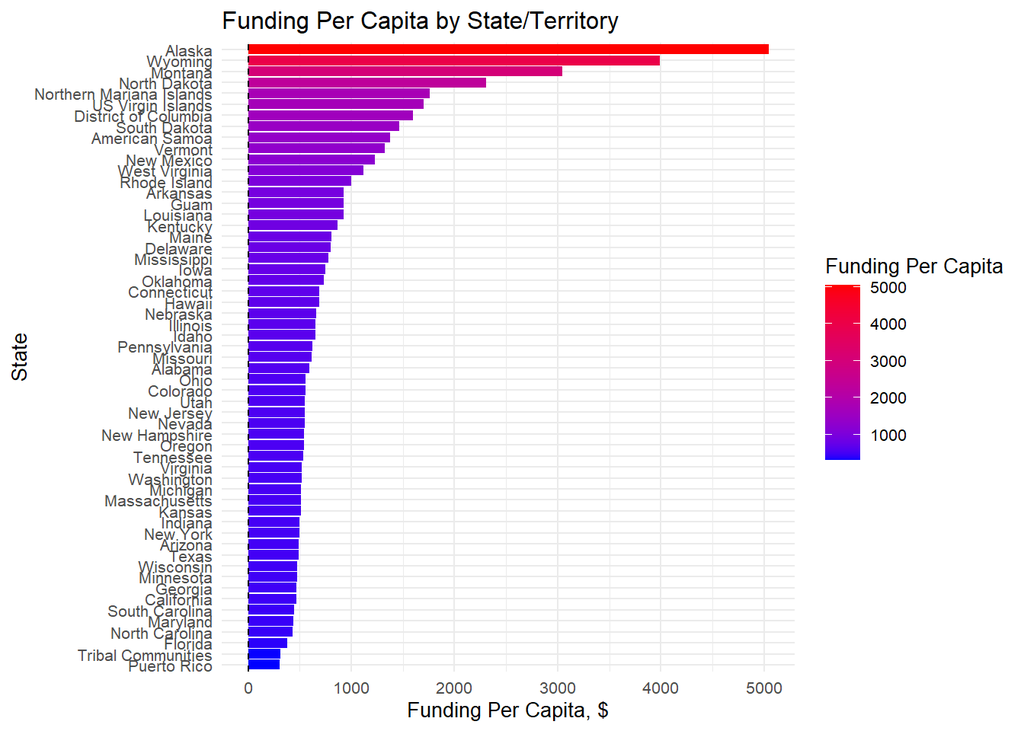

```r
sample_states <- first_df %>%
  arrange(desc(funding_per_capita)) %>%
  #slice_head(n = 20) %>%
  slice_head(n = 57) %>%
  pull(state)

sample_data <- first_df %>%
  filter(state %in% sample_states)


ggplot(sample_data) + geom_col(aes(x=funding_per_capita, y=reorder(state, funding_per_capita), fill=funding_per_capita)) +
  scale_fill_gradient(low="blue", high="red")+
  labs(title="Funding Per Capita by State/Territory",
       x="Funding Per Capita, $",
       y="State",
       fill="Funding Per Capita") +
  theme_minimal(base_size = 10) +
  geom_hline(yintercept=0, linetype="dashed") +
  geom_vline(xintercept=0, linetype="dashed")
```

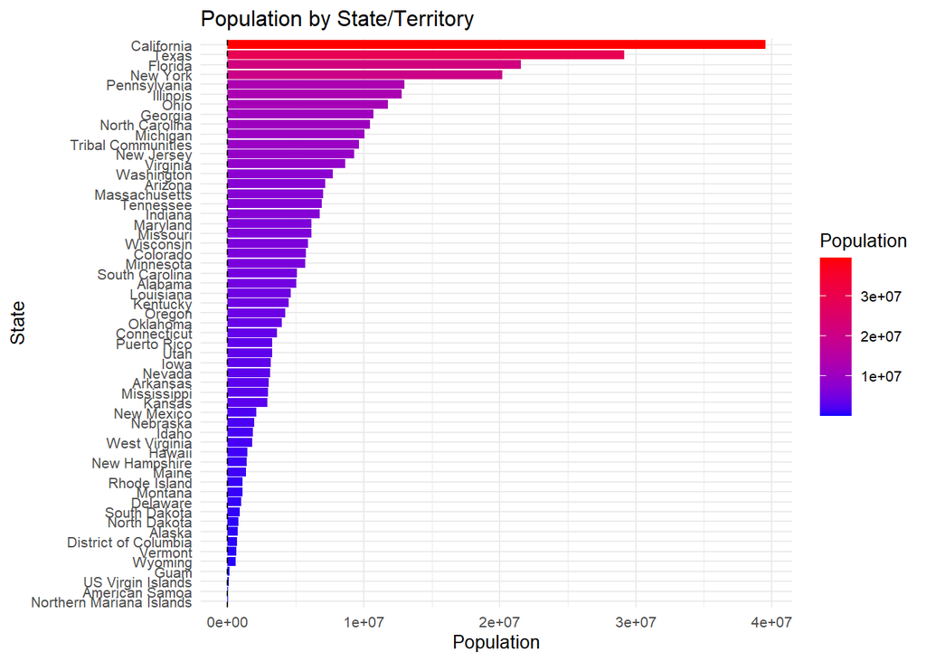

```r
sample_population <- first_df %>%
  arrange(desc(total_population)) %>%
 # slice_head(n = 20) %>%
  slice_head(n = 57) %>%
  pull(state)

sample_data <- first_df %>%
  filter(state %in% sample_population)

ggplot(sample_data) +
  geom_col(aes(x=total_population, y=reorder(state, total_population), fill=total_population)) +
  scale_fill_gradient(low="blue", high="red")+
  labs(title="Population by State/Territory",
       x="Population",
       y="State",
       fill="Population") +
  theme_minimal(base_size = 10) +
  geom_hline(yintercept=0, linetype="dashed") +
  geom_vline(xintercept=0, linetype="dashed")
```

This scatter plot expanded our understanding of the Infrastructure Investment and Jobs Act’s funding allocation in relation to state populations, adding a political dimension by displaying the 2020 Presidential Election results. Unlike the plots which depicted population sizes, and another plot, which displayed funding per capita, this visualization examined raw total funding against the backdrop of each state’s population size, as distinguished by the state’s political leaning in the most recent election. The plot indicated that, while there was a general trend of larger states receiving more total funding, the per capita analysis painted a different picture in which funding did not strictly scale with population. For example, some states with mid-range populations received more total funding than more populous states. This could be attributed to fixed infrastructure costs that did not scale linearly with population, or to targeted investments in specific projects within those states.Furthermore, an overlay of election results revealed that both states won by Biden and Trump were represented across the funding spectrum. There was no clear line that would indicate a political bias in overall funding allocation. States won by both parties received a variety of funding amounts that did not appear to be determined solely by population size.

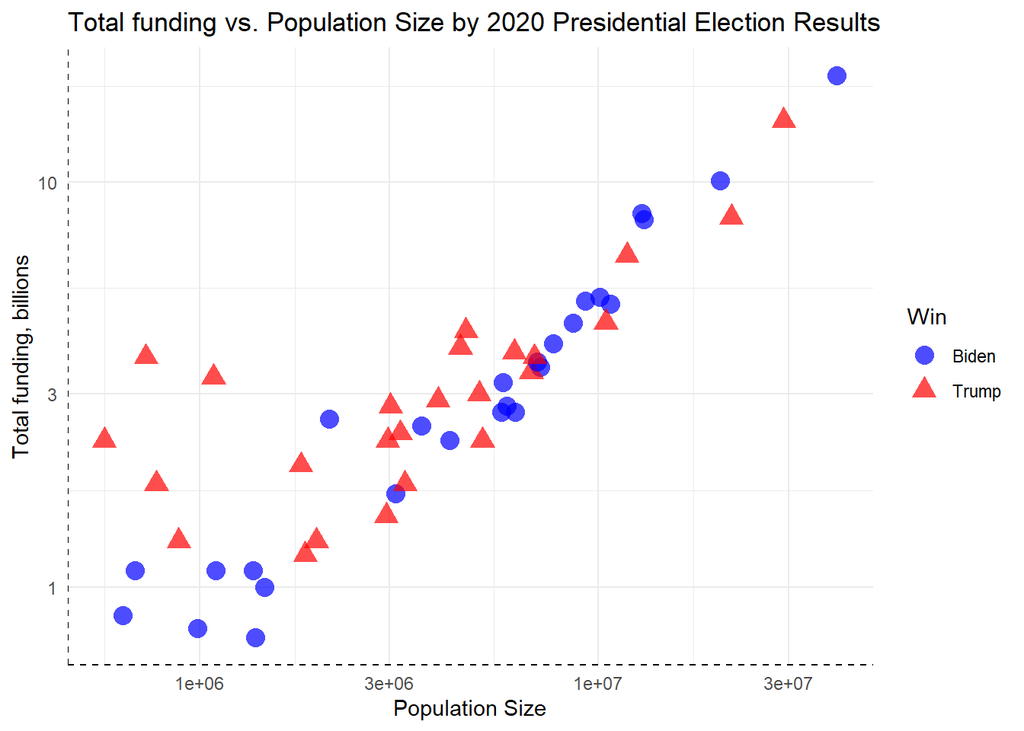

```r
ggplot(second_df, aes(x=total_population, y=total_billions, color=factor(win))) +
  geom_point(aes(shape = factor(win)), size=4, alpha=0.7) +
  scale_color_manual(values=c('Trump'='red', 'Biden'='blue')) +
  scale_x_log10() +
  scale_y_log10() +
  labs(title='Total funding vs. Population Size by 2020 Presidential Election Results',
       x='Population Size',
       y='Total funding, billions',
       color='Win',
       shape='Win') +
  theme_minimal() +
  theme(legend.position="right") +
  geom_hline(yintercept=0, linetype="dashed") +
  geom_vline(xintercept=0, linetype="dashed")
```

### 2.2 Question 2: Political Bias in Funding

This bar chart showed a nuanced distribution of funding per capita among the top recipients, with significant political diversity. States with smaller populations, such as Alaska and Wyoming, received the most funding per capita, which could indicate a distribution strategy that prioritized specific infrastructure projects or needs. The presence of both red and blue states in this top tier calls into question the notion of a purely political allocation process, pointing to a more complex decision-making framework that went beyond partisan considerations.

[figure not shown]

```r
sample_states <- second_df %>%
  arrange(desc(funding_per_capita)) %>%
  slice_head(n = 10) %>%
  pull(state)

sample_data <- second_df %>%
  filter(state %in% sample_states)

ggplot(sample_data, aes(x = reorder(state, funding_per_capita), y = funding_per_capita, fill = factor(win))) +
  geom_bar(stat = "identity", position = "dodge") +
  scale_fill_manual(values = c('Trump' = 'red', 'Biden' = 'blue'), labels = c('Trump', 'Biden'), name = "Win") +
  coord_flip() +
  labs(title = 'Top 10 States by Funding per Capita and 2020 Presidential Election Outcome',
       x = 'State',
       y = 'Funding per Capita, $',
       fill = "Win") +
  theme_minimal(base_size = 10) +
  guides(fill = guide_legend(title = "Win")) +
  geom_hline(yintercept=0, linetype="dashed") +
  geom_vline(xintercept=0, linetype="dashed")
```

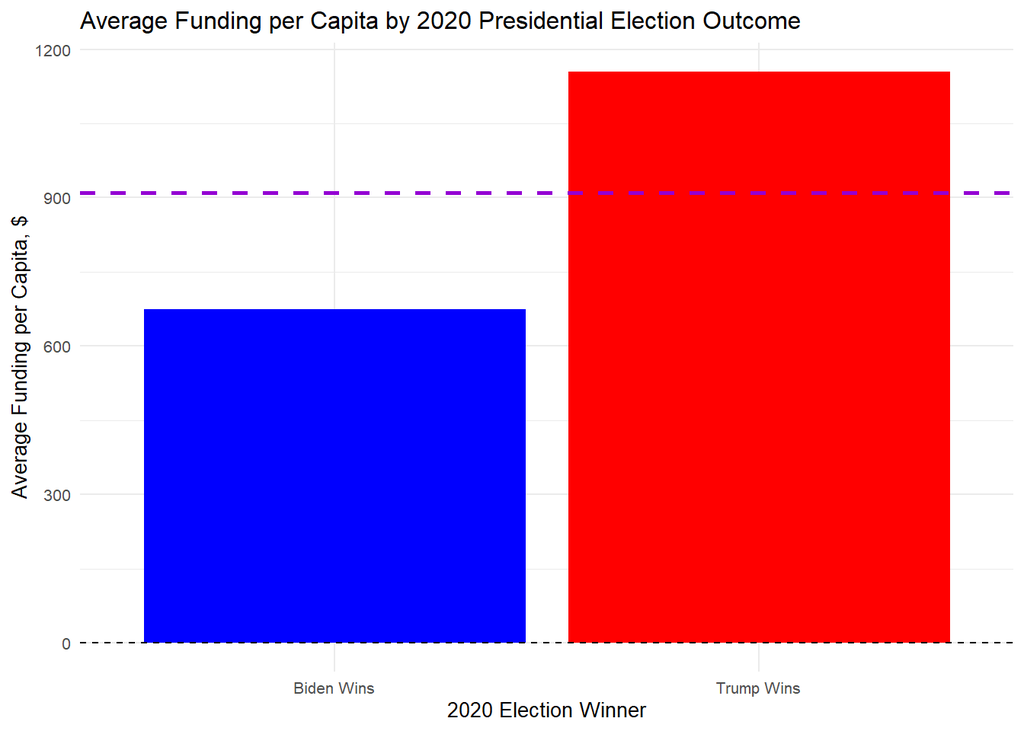

```r
election_outcome <- second_df %>%
  group_by(win) %>%
  summarise(funding_per_capita = mean(funding_per_capita)) %>%
  as.data.frame()

avg_funding <- mean(second_df$funding_per_capita)

ggplot(election_outcome, aes(x=factor(win, labels=c('Trump', 'Biden')), y=funding_per_capita, fill=factor(win))) +
  geom_bar(stat="identity", position="dodge") +
   geom_hline(yintercept=avg_funding, color='darkviolet', linetype='dashed', linewidth=1) +
  scale_fill_manual(values=c('blue', 'red')) +
  labs(title='Average Funding per Capita by 2020 Presidential Election Outcome',
       x='2020 Election Winner',
       y='Average Funding per Capita, $') +
  theme_minimal(base_size = 10) +
  theme(legend.position="none") +
  scale_x_discrete(labels=c('Biden Wins', 'Trump Wins')) +
  geom_hline(yintercept=0, linetype="dashed") +
  geom_vline(xintercept=0, linetype="dashed")
```

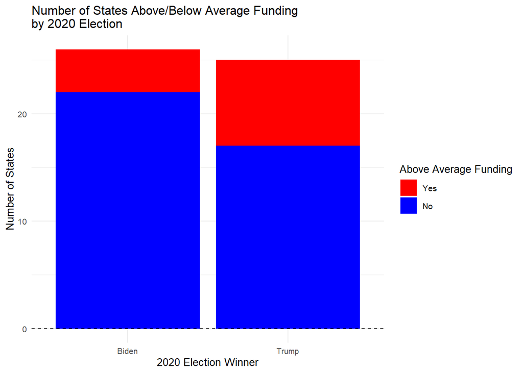

```r
second_df['above_avg_funding'] <- second_df['funding_per_capita'] > avg_funding

above_avg_funding_count <- as.data.frame(table(second_df$win, second_df$above_avg_funding))

above_avg_funding_count$Var1 <- factor(above_avg_funding_count$Var1, levels = unique(above_avg_funding_count$Var1))
above_avg_funding_count$Var2 <- factor(above_avg_funding_count$Var2, levels = c('TRUE', 'FALSE'), labels = c('Yes', 'No'))

ggplot(above_avg_funding_count, aes(x=Var1, y=Freq, fill=Var2)) +
  geom_bar(stat="identity", position="stack") +
  labs(title='Number of States Above/Below Average Funding\nby 2020 Election',
       x='2020 Election Winner', y='Number of States') +
  scale_fill_manual(values=c('Yes'='red', 'No'='blue'), name="Above Average Funding") +
  theme_minimal(base_size = 10) +
  guides(fill=guide_legend(title="Above Average Funding")) +
  geom_hline(yintercept=0, linetype="dashed") +
  geom_vline(xintercept=0, linetype="dashed")
```

## 3. Conclusions

The bar charts and scatter plots depict a distribution strategy that takes into account a wide range of factors, including each state’s unique infrastructure needs, geographical considerations, and the cost of living and construction. States with smaller populations, such as Alaska and North Dakota, as well as unique entities like the District of Columbia, receive more funding per capita, which may reflect these additional considerations.

It’s also worth noting that states that supported both President Biden and former President Trump have a wide range of funding levels. This distribution indicates a degree of neutrality in the allocation process, implying that political preferences did not solely determine funding outcomes.

As we examine these allocations, the visual narratives highlight the importance of a data-driven approach to policy evaluation, recognizing that infrastructure needs vary across the country. Our findings suggest that while the allocation process may strive for equitable development, it also points to the need for transparency and ongoing analysis to fully understand the underlying principles guiding these significant federal investments.

## References

1. Knaflic, C. N. (2015). Storytelling with Data. https://doi.org/10.1002/9781119055259
2. US Census Bureau. (2023, December 18). State Population Totals and Components of Change: 2020-2023. Census.gov. https://www.census.gov/data/datasets/time-series/demo/popest/2020s-state-total.html
3. 2020 | The American Presidency Project. (n.d.). https://www.presidency.ucsb.edu/statistics/elections/2020
4. Cook Political Report. (n.d.). 2020 Popular Vote Tracker | Cook Political Report. https://www.cookpolitical.com/2020-national-popular-vote-tracker
5. Wikipedia contributors. (2024, February 1). List of U.S. states and territories by population. Wikipedia. https://en.wikipedia.org/wiki/List_of_U.S._states_and_territories_by_population
6. Wikipedia contributors. (2024a, January 27). Native Americans in the United States. Wikipedia. https://en.wikipedia.org/wiki/Native_Americans_in_the_United_States
7. Ex-Pr. (n.d.). GitHub - ex-pr/DATA_608. GitHub. https://github.com/ex-pr/DATA_608/tree/main
8. The Data Visualisation catalogue. (n.d.). https://datavizcatalogue.com/index.html